# HW7

Desmond Fung

4/25/2020

## Problem 1: (25 points)

```r
head(data.deug)
```

|  | Algebra | Analysis | Proba | Informatic | Economy | Option1 | Option2 | English | Sport |
| --- | --- | --- | --- | --- | --- | --- | --- | --- | --- |
| 1 | 40 | 26.0 | 26 | 26.0 | 51.9 | 17 | 24 | 19.0 | 11.5 |
| 2 | 37 | 34.5 | 37 | 32.0 | 72.0 | 24 | 22 | 26.0 | 11.5 |
| 3 | 37 | 41.0 | 29 | 34.5 | 72.0 | 24 | 27 | 19.6 | 11.5 |
| 4 | 63 | 37.5 | 57 | 35.5 | 77.4 | 23 | 23 | 21.0 | 14.0 |
| 5 | 55 | 31.5 | 34 | 36.0 | 57.9 | 19 | 24 | 24.0 | 11.5 |
| 6 | 50 | 38.0 | 32 | 20.0 | 66.9 | 20 | 15 | 22.2 | 0.0 |

Present the data analysis report to obtain the best PCR and their interpretation using the data set deug. Do the following:

### a. (3 points/25) Present the Exploratory Visualization: Scatterplot, correlation matrix plot, Boxplot, Mean and Variances.

## Scatterplot

```r
library("PerformanceAnalytics")
```

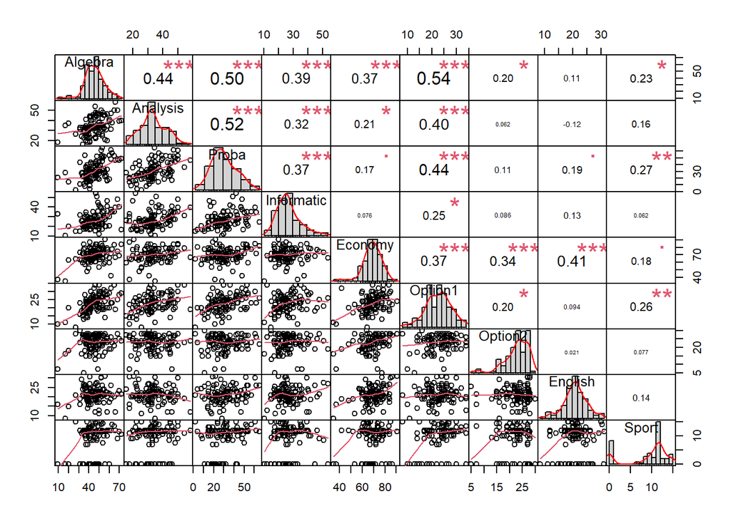

```r
chart.Correlation(data.deug, histogram = TRUE, pch = 15)
```

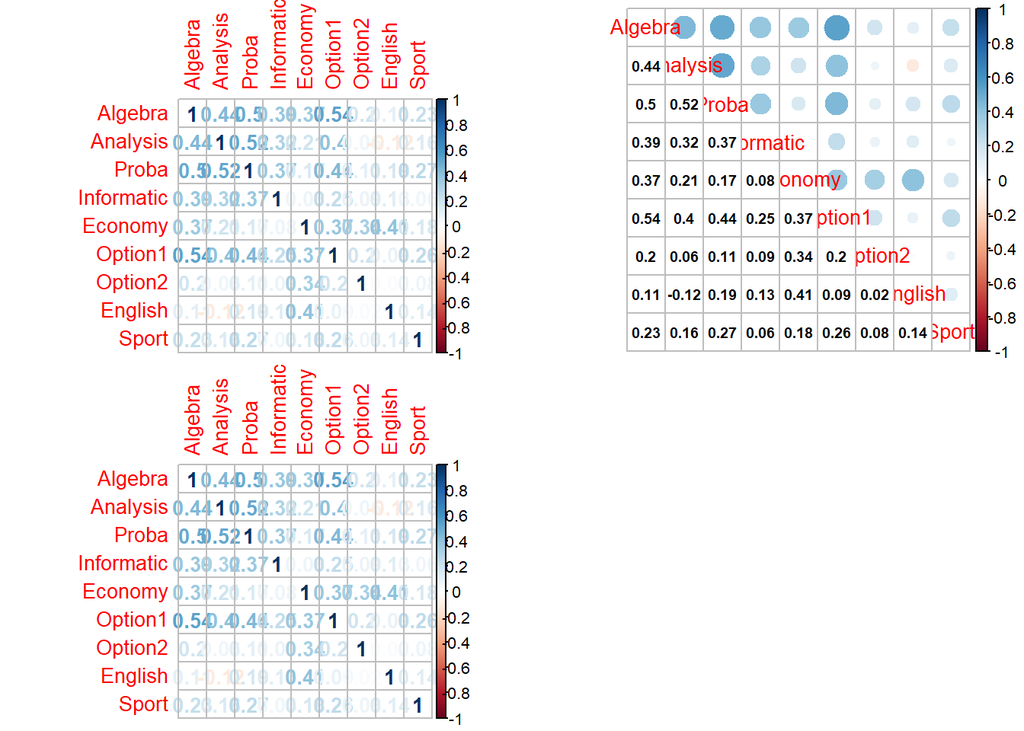

```r
# install.packages("corrplot")
library(corrplot)
par(mfrow=c(2,2))

corrMat<-cor(data.deug)

corrplot(corrMat, method = "number")
corrplot.mixed(corrMat, lower.col = "black", number.cex = .7)

corrplot(corrMat, method = "number") # Display the correlation coefficient
```

## Boxplot

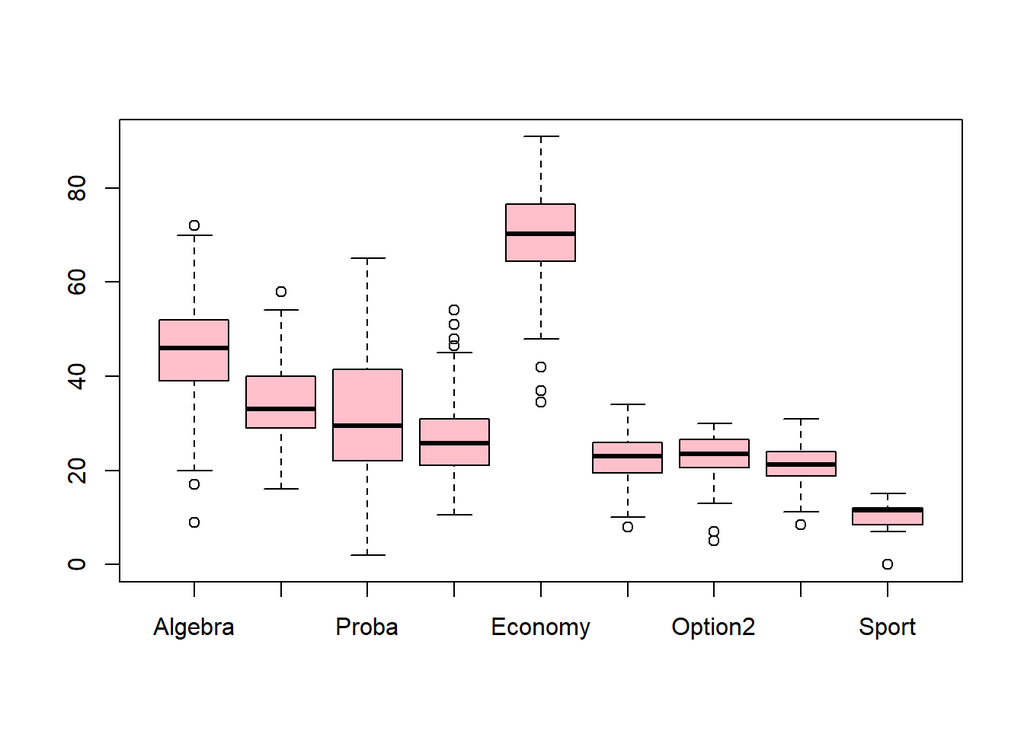

```r
boxplot(data.deug, col="pink")
```

## Mean and Variances

```r
apply(data.deug,2,mean) #mean
```

```
##    Algebra   Analysis      Proba Informatic    Economy    Option1    Option2
##  45.567308  33.985577  31.240385  26.990385  69.550962  22.750000  22.668269
##    English      Sport
##  21.125962   9.230769
```

```r
apply(data.deug,2,sd) #Variances
```

```
##    Algebra   Analysis      Proba Informatic    Economy    Option1    Option2
##  10.489722   8.811802  13.381987   8.247383   9.609744   5.204087   4.759564
##    English      Sport
##   4.261956   4.944313
```

If we failed to scale the variables before performing PCA, then most of PCs that we observed would be driven by the some variables, because they have the largest mean and variation. Thus, it is important to standardize the variables to have mean zero and standard deviation one before performing PCA.

### b. (3 points/25) Compute the correlation matrix (using the center and scaled data).

## Standardize the data (Center and scale)

```r
deug.centered <- scale(data.deug,scale=TRUE,center=TRUE)
head(deug.centered)
```

```
##      Algebra    Analysis       Proba Informatic    Economy     Option1
## 1 -0.5307393 -0.90623657 -0.39159989 -0.1200847 -1.8367775 -1.10490076
## 2 -0.8167336  0.05837888  0.43040061  0.6074188  0.2548495  0.24019582
## 3 -0.8167336  0.79602598 -0.16741793  0.9105453  0.2548495  0.24019582
## 4  1.6618832  0.39883139  1.92494697  1.0317958  0.8167791  0.04803916
## 5  0.8992319 -0.28207364  0.20621866  1.0924211 -1.2124112 -0.72058746
## 6  0.4225748  0.45557347  0.05676402 -0.8475882 -0.2758618 -0.52843080
##       Option2     English      Sport
## 1  0.27980100 -0.49882294  0.4589578
## 2 -0.14040556  1.14361533  0.4589578
## 3  0.91011084 -0.35804252  0.4589578
## 4  0.06969772 -0.02955486  0.9645892
## 5  0.27980100  0.67434725  0.4589578
## 6 -1.61112851  0.25200598 -1.8669469
```

Compute the correlation matrix

```r
(Sigma = cor(data.deug)) #Compute the correlation matrix (using the center and scaled data).
```

```
##              Algebra    Analysis     Proba Informatic    Economy   Option1
## Algebra    1.0000000  0.44496518 0.5042599 0.38858039 0.36587492 0.5367073
## Analysis   0.4449652  1.00000000 0.5164676 0.31995199 0.20681450 0.4044038
## Proba      0.5042599  0.51646761 1.0000000 0.37287463 0.16706197 0.4440595
## Informatic 0.3885804  0.31995199 0.3728746 1.00000000 0.07564364 0.2496737
## Economy    0.3658749  0.20681450 0.1670620 0.07564364 1.00000000 0.3714455
## Option1    0.5367073  0.40440385 0.4440595 0.24967368 0.37144552 1.0000000
## Option2    0.1963220  0.06157671 0.1118533 0.08580382 0.33924787 0.2039705
## English    0.1140047 -0.11973500 0.1869370 0.13095780 0.40634881 0.0938390
## Sport      0.2347202  0.15834887 0.2693675 0.06243446 0.17844197 0.2594090
##               Option2     English      Sport
## Algebra    0.19632201  0.11400473 0.23472019
## Analysis   0.06157671 -0.11973500 0.15834887
## Proba      0.11185328  0.18693698 0.26936752
## Informatic 0.08580382  0.13095780 0.06243446
## Economy    0.33924787  0.40634881 0.17844197
## Option1    0.20397055  0.09383900 0.25940896
## Option2    1.00000000  0.02127238 0.07661760
## English    0.02127238  1.00000000 0.13728734
## Sport      0.07661760  0.13728734 1.00000000
```

### c. (3 points/25) Compute the principal components (PCs) using the correlation matrix

#### Compute the Eigenvectors and Eigenvalues from the correlation matrix.

```r
evec = eigen(Sigma)$vectors
(eval = eigen(Sigma)$values)
```

```
## [1] 3.1013578 1.3629834 1.0323269 0.9340533 0.7397529 0.5746693 0.5325414
## [8] 0.4375395 0.2847754
```

λ1= 3.1013578  
λ2= 1.3629834  
λ3= 1.0323269  
λ4= 0.9340533  
λ5= 0.7397529  
λ6= 0.5746693  
λ7= 0.5325414  
λ8= 0.4375395  
λ9= 0.2847754

With this ordering, then the $i^{th}$ PC is the $i^{th}$ eigenvector corresponding to $λ_i$. represents our principal components.

### d. (3 points/25) Write the expression for each principal component

λ1= 3.1013578 = $Var(Z_1)$  
λ2= 1.3629834 = $Var(Z_2)$  
λ3= 1.0323269 = $Var(Z_3)$  
λ4= 0.9340533 = $Var(Z_4)$  
λ5= 0.7397529 = $Var(Z_5)$  
λ6= 0.5746693 = $Var(Z_6)$  
λ7= 0.5325414 = $Var(Z_7)$  
λ8= 0.4375395 = $Var(Z_8)$  
λ9= 0.2847754 = $Var(Z_9)$

### e. (3 points/25) Compute the PCs from the Singular Value Decomposition (SVD).

## Compute the PCs grom the Singular Value Decomposition(SVD).

```r
pr.out <- prcomp(data.deug, scale=TRUE)

pr.out$rotation
```

```
##                  PC1         PC2        PC3         PC4         PC5         PC6
## Algebra    0.4499972 -0.07914523  0.0471192 -0.06031393  0.09364452 -0.35788011
## Analysis   0.3709055 -0.39627195  0.1062237  0.04140274  0.29340513  0.46128485
## Proba      0.4207824 -0.20740106 -0.2092587  0.01933918 -0.07006815  0.50306851
## Informatic 0.3002324 -0.24091467 -0.2375823 -0.53216019 -0.50423346 -0.27346361
## Economy    0.3145059  0.53687259  0.1442512 -0.06352658  0.35740240  0.02659076
## Option1    0.4211180 -0.01371946  0.1419643  0.13812595  0.27108324 -0.48696475
## Option2    0.1894393  0.32205782  0.6905267 -0.14506372 -0.49097358  0.23677894
## English    0.1564407  0.57374155 -0.5728454 -0.21630766  0.02022396  0.18099207
## Sport      0.2368946  0.11970164 -0.2007995  0.78748504 -0.45088419 -0.06792421
##                    PC7         PC8         PC9
## Algebra    -0.06047918  0.77634677 -0.20533160
## Analysis    0.42112415 -0.16366337 -0.43519930
## Proba      -0.49482138  0.07698087  0.47644731
## Informatic  0.33309171 -0.22661684  0.14436684
## Economy     0.44630634 -0.00238415  0.51026585
## Option1    -0.39603411 -0.55488478 -0.08875721
## Option2    -0.15766204 -0.02684335 -0.19955864
## English    -0.14654224 -0.06652162 -0.46080281
## Sport       0.24664572 -0.01304809 -0.01359074
```

```r
(pr.out$sdev)^2
```

```
## [1] 3.1013578 1.3629834 1.0323269 0.9340533 0.7397529 0.5746693 0.5325414
## [8] 0.4375395 0.2847754
```

### f. (3 points/25) Present the scree plot and interpret it.

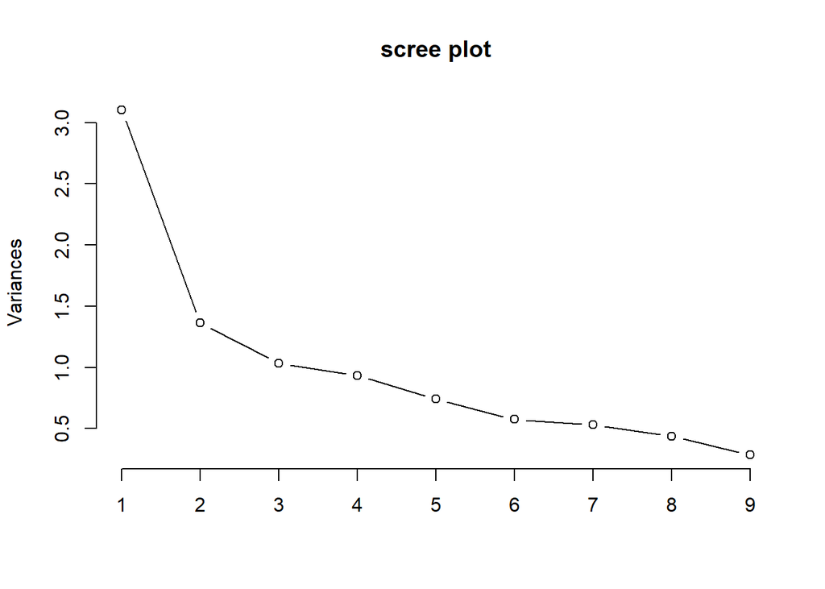

```r
plot(pr.out,type="l", main = "scree plot")
```

```r
(pve = eval/sum(eval))
```

```
## [1] 0.34459531 0.15144260 0.11470299 0.10378370 0.08219477 0.06385214 0.05917127
## [8] 0.04861550 0.03164171
```

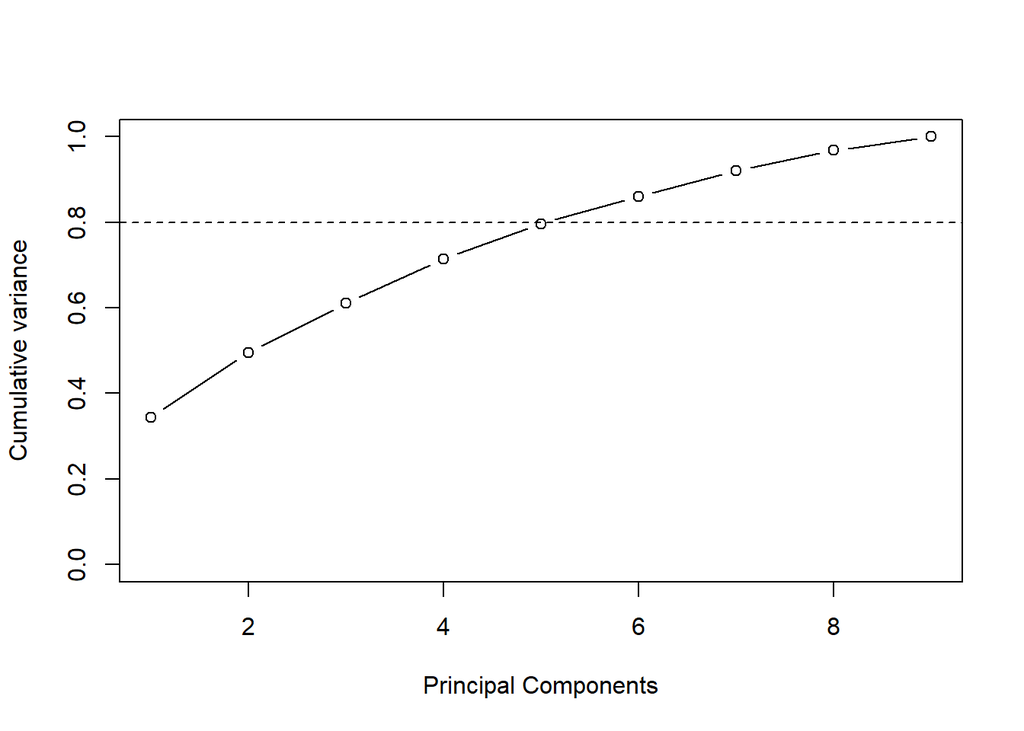

```r
yvec = cumsum(pve)
plot(yvec, type='b', xlab="Principal Components", ,
   ylab="Cumulative variance", main = " ", ylim=c(0,1))
   abline(h=0.8,lty=2)
```

### g. (3 points/25) Select the best PCs using the Elbow rule

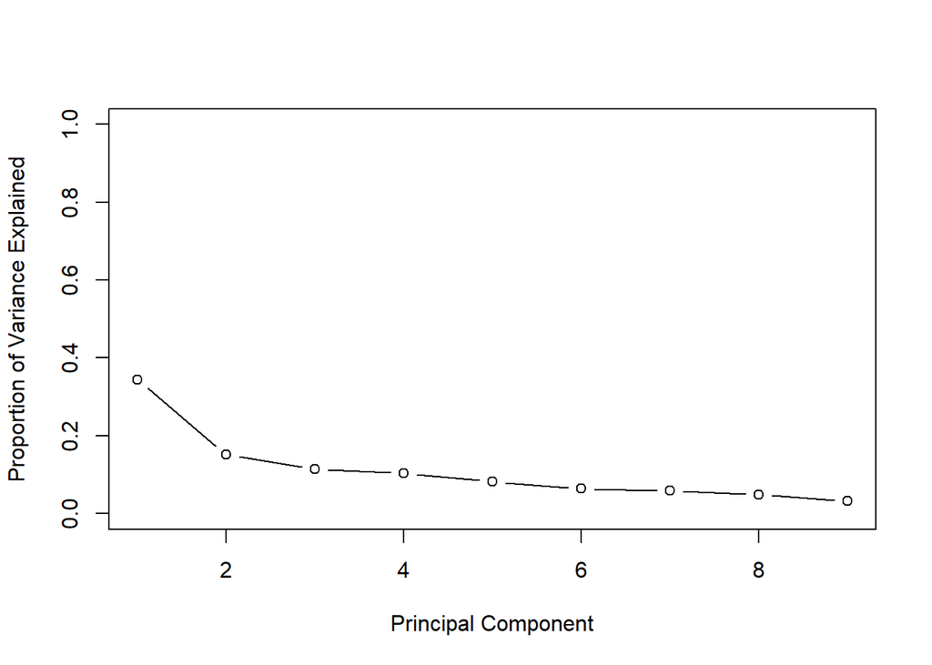

```r
plot(pve, xlab="Principal Component", type='b',
  ylab="Proportion of Variance Explained", ylim=c(0,1))
```

Elbow rule in determining which PCs to look at – basically find the cut-off where the shape of the curve looks like an elbow. Therefore, the best PCs is 2.

### h. (4 points/25) Present and interpret the Biplot

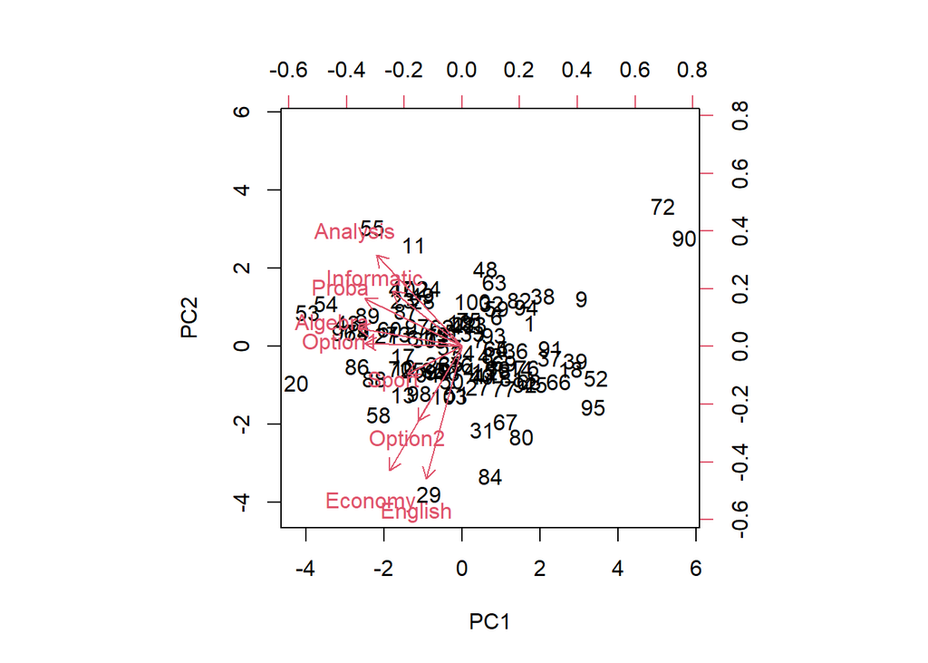

```r
# Plot the first two PCs

pr.out$rotation = -pr.out$rotation
pr.out$x = -pr.out$x
biplot(pr.out, scale=0)
```

```r
library(devtools)
```

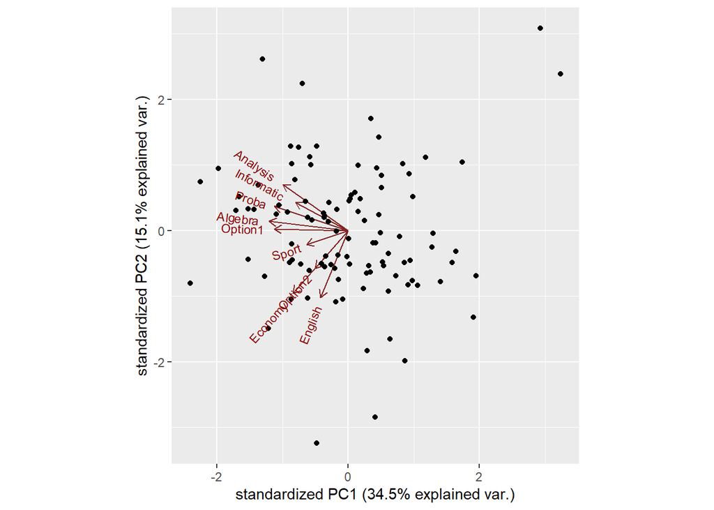

```r
library(ggbiplot)
ggbiplot(pr.out)
```

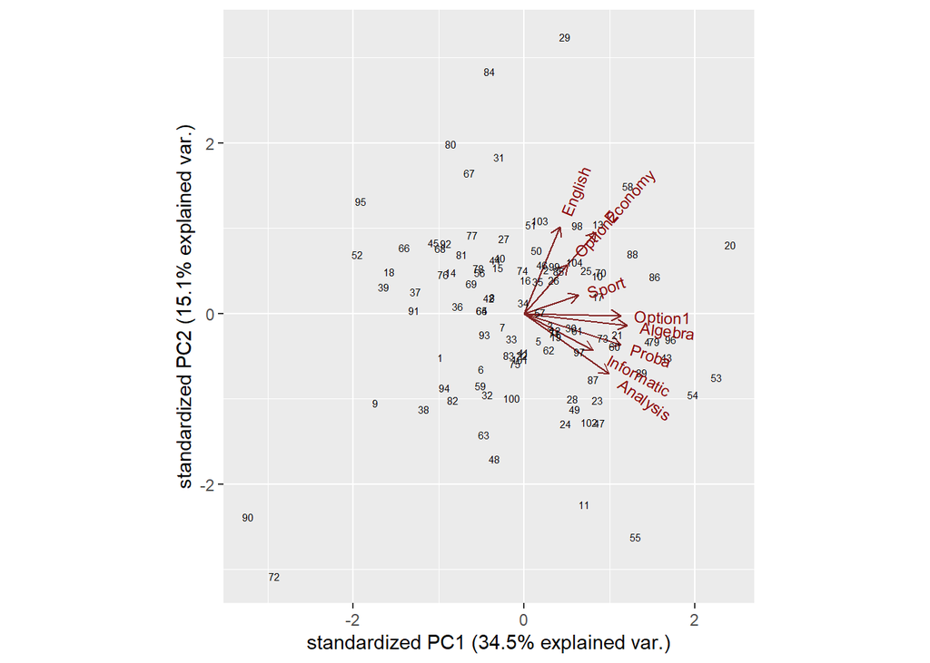

```r
pr.out$rotation = -pr.out$rotation
pr.out$x = -pr.out$x
ggbiplot(pr.out, labels=rownames(data.deug),labels.size = 2,varname.size = 3)
```

```r
pr.out$rotation[,1:2]
```

```
##                  PC1         PC2
## Algebra    0.4499972 -0.07914523
## Analysis   0.3709055 -0.39627195
## Proba      0.4207824 -0.20740106
## Informatic 0.3002324 -0.24091467
## Economy    0.3145059  0.53687259
## Option1    0.4211180 -0.01371946
## Option2    0.1894393  0.32205782
## English    0.1564407  0.57374155
## Sport      0.2368946  0.11970164
```

Biplot displays both the PC scores and the loadings.

## Problem 2: (25 points)

### a. (5 points/25) Calculates pcr and uses cross-validation to determine the number of component. To be reproducible use set.seed(23).

```r
#install.packages("pls")
library(pls)
set.seed(23)
pcr.fit = pcr(Algebra~., data=data.deug, scale=TRUE,validation="CV")
summary(pcr.fit)
```

```
## Data:    X dimension: 104 8
##  Y dimension: 104 1
## Fit method: svdpc
## Number of components considered: 8
##
## VALIDATION: RMSEP
## Cross-validated using 10 random segments.
##        (Intercept)  1 comps  2 comps  3 comps  4 comps  5 comps  6 comps
## CV           10.54    8.147    8.348    8.450    8.572    8.703    8.792
## adjCV        10.54    8.131    8.315    8.412    8.527    8.650    8.722
##        7 comps  8 comps
## CV       9.017    9.041
## adjCV    8.946    8.966
##
## TRAINING: % variance explained
##          1 comps  2 comps  3 comps  4 comps  5 comps  6 comps  7 comps  8 comps
## X          32.12    49.06    61.94    73.59    82.79    89.69    96.33   100.00
## Algebra    43.29    44.04    44.17    44.32    44.47    45.09    45.15    45.74
```

### b. (5 points/25) Interpret the summary of the function pcr.

Cross-validated using 10 random segments.

The summary() function provides **the percentage of variance explained in the predictors and in the response using different numbers of components.**

we can think of this as the amount of information about the predictors or the response that is captured using M principal components. For example, setting M=1 only captures **32.12%** of all the variance, or information, in the predictors.

In contrast, using M=7 increases the value to **96.33%**. If we were to use all M=p=8 components, this would increase to 100%.

### c. (5 points/25) Plot cross-validation Mean Square Error Prediction (MSEP)

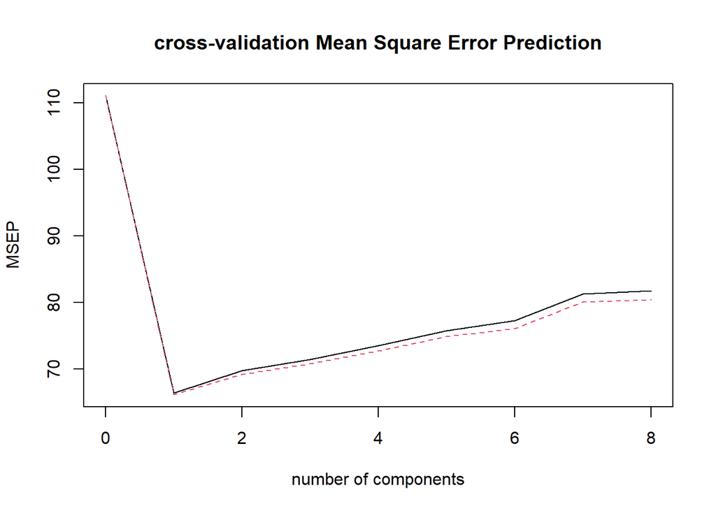

```r
validationplot(pcr.fit ,val.type="MSEP", main = "cross-validation Mean Square Error Prediction")
```

We see that the smallest cross-validation error (MSEP) occurs when M=1 components are used.

### d. (5 points/25) Perform PCR on the training data (select 50%) with the right number of components and evaluate its test set performance. Plots MSE by number of components. To be reproducible use set.seed(24)

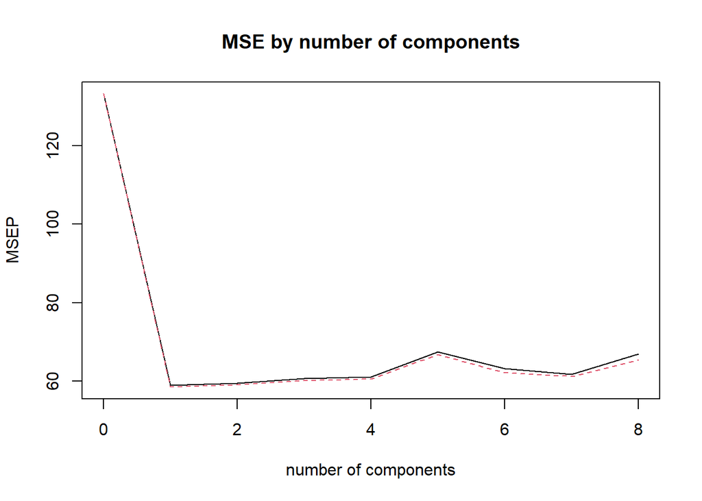

```r
set.seed(24)
train = sample(1:nrow(data.deug), nrow(data.deug)/2) # select  50% of the total data (nrow(data.deug)/2=104/2=52) as the training sample.


pcr.fit2 =pcr(Algebra~., data=data.deug ,subset=train ,scale=TRUE , validation ="CV")


validationplot(pcr.fit2 ,val.type="MSEP", main ="MSE by number of components")
```

## Test set performance

```r
x = model.matrix(Algebra~.,data.deug)[,-1]
y = data.deug$Algebra
test = (-train)
pcr.pred = predict(pcr.fit,x[test,],ncomp=5)
y.test = y[test]
(mean((pcr.pred-y.test)^2)) # test MSE
```

```
## [1] 65.3277
```

However, as a result of the way PCR is implemented, the final model is more difficult to interpret because it does not perform any kind of variable selection or even directly produce coefficient estimates.

### e. (5 points/25) Perform PCR on the full data

```r
library(ISLR)
pcr.fit7 = pcr(Algebra~.,data=data.deug,scale=TRUE,ncomp=5)
summary(pcr.fit7)
```

```
## Data:    X dimension: 104 8
##  Y dimension: 104 1
## Fit method: svdpc
## Number of components considered: 5
## TRAINING: % variance explained
##          1 comps  2 comps  3 comps  4 comps  5 comps
## X          32.12    49.06    61.94    73.59    82.79
## Algebra    43.29    44.04    44.17    44.32    44.47
```